# Final - Short

### loading Data

```r
#settings used in the sumilation
  #sart dom: 0%
  #dom live: 50%
  #rec live: 75%
  #mutation:  3%
PopPath = '../Final - Datasets and Analysis/Populations/'
Pop <- read.csv(PopPath %.% 'Population25.csv')[-4] #removing predator column since it is not used
attach(Pop)
  Pop$Tot = Rec+Dom+Het

  GeneA <- 2*Dom+Het
  GeneB <- 2*Rec+Het
  Pop$perc <- GeneB/(2*Pop$Tot) #percentage rec genes (gene B)

detach(Pop)


M = nrow(Pop)
N = 1:M
```

### Modeling with Arctangent

```r
X <- N
Y = Pop$perc

#normalize
YY <- Y - ((min(Y)+max(Y))/2)
Y0 <- which.min(abs(YY)) #where the 0s of this YY is. not quite the correct 0, so the fit won't be perfect
X_ <- X - Y0


Y.norm <- function(y) {
  y1 <- y - ((min(y)+max(y))/2)
  y_ <- y1 * atan(max(X_)) / max(y1)
  eval.parent(substitute(y.max <- max(y1)))
  return(y_)
}

Y.denorm <- function(y_) {
  y1 <- y_ / atan(max(X_)) * y.max
  y <- y1 + ((min(Y)+max(Y))/2)
  return(y)
}


Y_ <- Y.norm(Y)

#take tanget
Y2 <- tan(Y_)

Coeff <- rev(P.m(X_,y=Y,reg=T,degree = 1));print.(c('a = ','b = ') %.% Coeff) #do linear regression by using projection matrix
```

a = 0.0347709377987493 b = 0.423420493637297

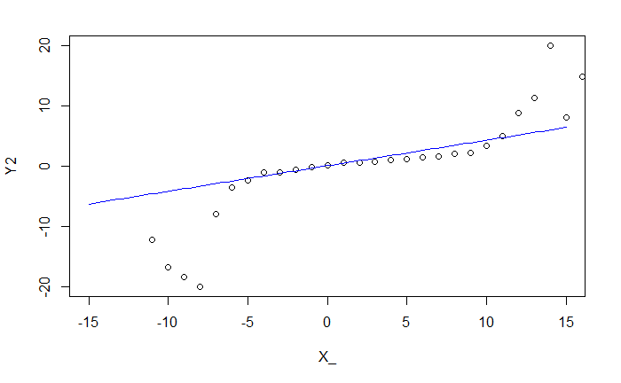

```r
fLine <- function(x) {
  Coeff[1]+Coeff[2]*x
}
plot(X_,Y2,xlim=c(-15,15))
curve(fLine(x),add = TRUE,col='blue')
```

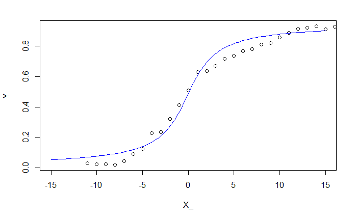

```r
#undo tanget


y.detan <- function(x) {
  Y.denorm(atan(fLine(x)))
}


suppressWarnings(plot(X_,Y,xlim=c(-15,15)))
 curve(y.detan(x),add = TRUE,col='blue')
```

```r
#get values and scale data to have area equal to the number of data points for χ2 test
scale <- max(Pop$Tot) #scale by number of data points
expect  <- y.detan(X_) * scale / sum(Y)
observe <-Y * scale / sum(Y)


X_2 <- chisq.stat(observe,expect); print.('$\\chi^2\\ =\\ '%+%X_2%+% '$.')
```

$\chi^2\ =\ 1.22713476178509$.

```r
pchisq(X_2,29,lower.tail = FALSE); print.('This value is pretty high. ~0.8. That shows that this is a pretty good fit (which can easily be seen). Overall it is quite interesting that an arctanget curve was the best fit.')
```

[output not shown]

### population change matrix

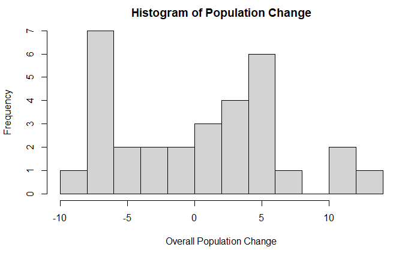

```r
PopChange <- matrix(nrow = M,ncol = ncol(Pop)); colnames(PopChange) <- colnames(Pop) %.% '.inc' #initialize population change matrix
for (i in 2:M) {
  PopChange[i,] <- as.matrix(Pop)[i,]-as.matrix(Pop)[i-1,] #make each row the change since the previous generation
}
PopChange <- as.data.frame(PopChange) #convert population change matrix to a data-frame

# Make boolean columns for if the variable increased
for (Col in colnames(Pop)) {
  ColNum <- Col %.% '.inc'
  ColBool <- Col %.% '.bool'
  PopChange[ColBool] <- PopChange[ColNum] > 0 # if the variable increased since the last generation
}

hist(PopChange$Tot.inc,breaks = 15,xlab = 'Overall Population Change',main = 'Histogram of Population Change')
```

```r
print.('We see an interesting spike around -8 and another around 5, but a gap near 8')
```

```
We see an interesting spike around -8 and another around 5, but a gap near 8
```

#### % Change with $\chi^2$ fit

```r
pChange <- PopChange$perc.inc[-1]
len <- length(pChange)

pChange.sum <- sum(pChange)
pChange.norm <- pChange/pChange.sum #normalized data
pChange.df <- sum(pChange.norm*1:len);print.(pChange.df) #calculates the mean, which is then used as the degrees of freedom
```

11.17577

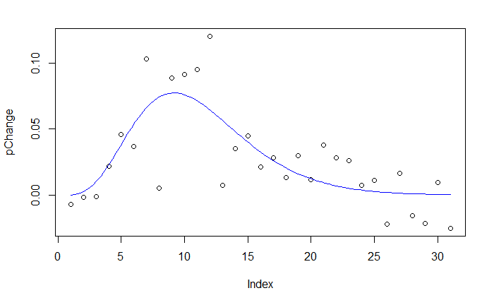

```r
scale <- integrate(dchisq,df=pChange.df,1,len)$value #area under χ2, used to scale the

x2 <- function(x) {
  ans <- dchisq(x,pChange.df) #χ2 fitted to the correct degrees of freedom
  ans %/=% scale              #divide by area under curve to normalize
  ans %*=% pChange.sum        #multiply by the area it should have
  return(ans)
}


plot(pChange)
curve(x2(x),add = T,col='blue') #plots the scaled and fitted χ2
```

```r
Expect  <- x2(1:len)
Observe <- pChange



t.test(Observe,Expect); print.('We get a P-value of', t.test(Observe,Expect)$p.value ,'which shows that these likely come from the same distribution.')
```

```
Welch Two Sample t-test
```

data: Observe and Expect t = -0.00081078, df = 55.014, p-value = 0.9994 alternative hypothesis: true difference in means is not equal to 0 95 percent confidence interval: -0.01680231 0.01678872 sample estimates: mean of x mean of y 0.02725806 0.02726486

We get a P-value of 0.999356 which shows that these likely come from the same distribution.

```r
#Do with χ2 (this means that the data needs to be scaled)
Expect  %*=% (len / sum(pChange))
Observe  %*=% (len / sum(pChange))

X_2 <- chisq.stat(Observe,Expect); print.('$\\chi^2\\ =\\ '%+%X_2%+% '$.')
```

$\chi^2\ =\ 146.198774386747$.

```r
pchisq(X_2,29,lower.tail = FALSE); print.('<br> However, when we do a $\\chi^2$ test, we end up with a very low P-value, which would suggest that this is a bad fit.','<br><br>','It should also be noted that for both of these tests the null hypothesis is that the two data points come from the same distribution, meaning that a high P-value means that they are related. (unlike a permutation test which has independance as the null and thus the reverse meaning of P-values)')
```

[1] 1.379734e-17  
However, when we do a $\chi^2$ test, we end up with a very low P-value, which would suggest that this is a bad fit.  
It should also be noted that for both of these tests the null hypothesis is that the two data points come from the same distribution, meaning that a high P-value means that they are related. (unlike a permutation test which has independance as the null and thus the reverse meaning of P-values)